# Sarah Lab 10

Sarah

March 21, 2018

## Sarah Individual

### Questions

I chose to analyze the number of question marks in each question. This will give an idea of how many different aspects of a single problem each post is asking about. It will be interesting to see whether more questions result in more specificity and therefore higher ratings, or if they result in more confusion and lower ratings.

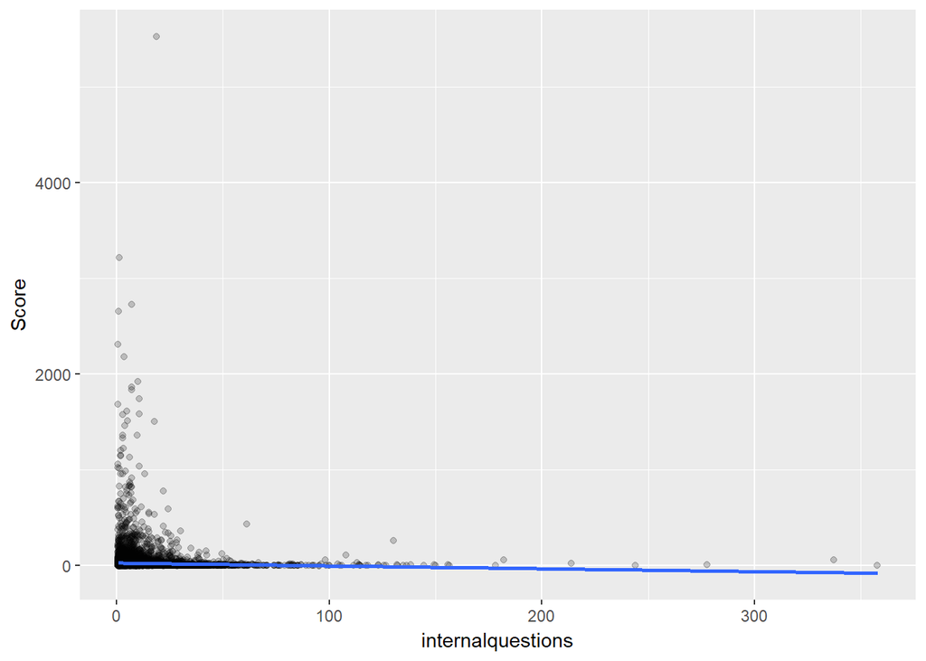

There are some questions with an absurdly large number of question marks in them. The scores tend to be lower the more question marks there are; however, I will examine the trends in the majority of the data points by filtering out those with very high scores or those with very high numbers of question marks.

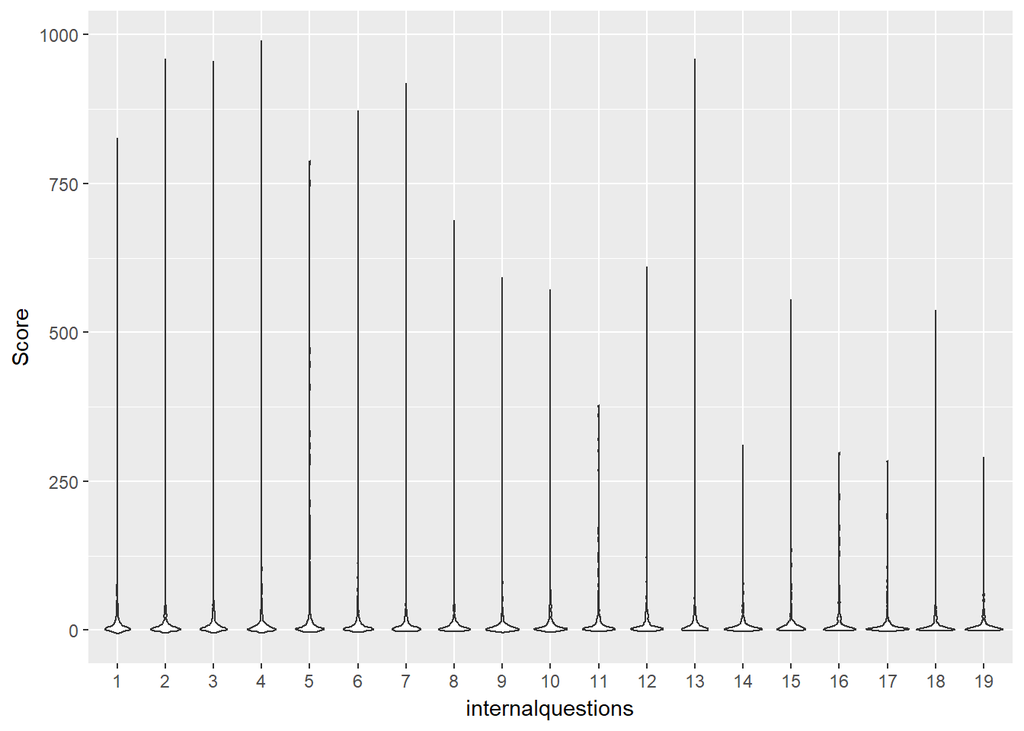

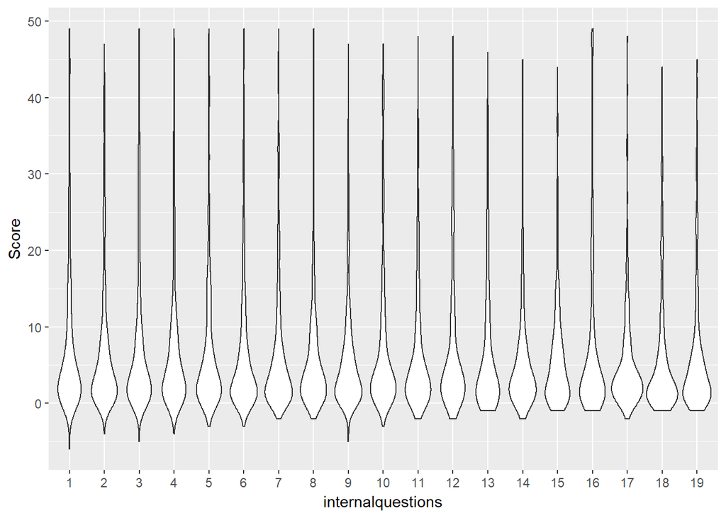

There don’t seem to be any noticable trends in the most common numbers of question marks within a question and their scores.

### Answers

I chose to analyze how many paragraphs an answer has and what relationship that might have with the scores an answer received. Exploring this will allow us to see if breaking an answer into more pargraphs and writing a long enough answer that requires paragraphs results in higher scores, or if more succinct answers tend to do better.

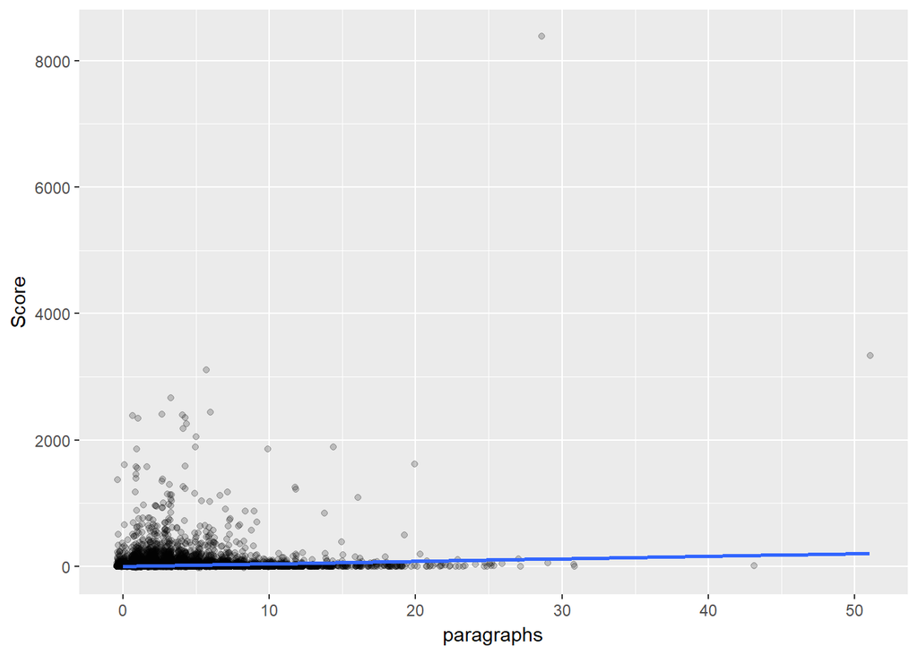

From this plot, it appears that there are some anwers with absurdly large scores and number of paragraphs that are making it difficult to see the general trend of the majority of the dataset, so I will filter those out so we can look at the patterns of the more commons scores and paragraph numbers.

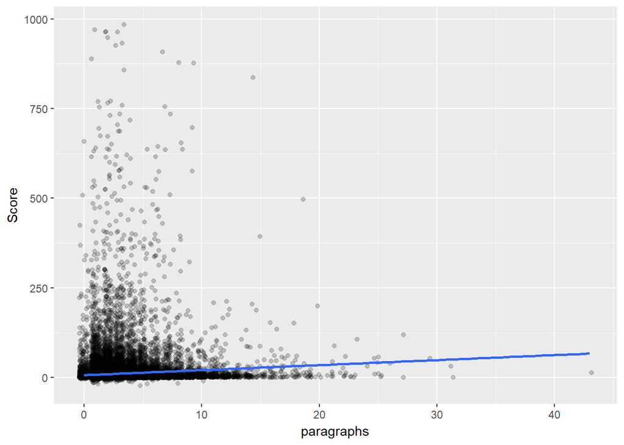

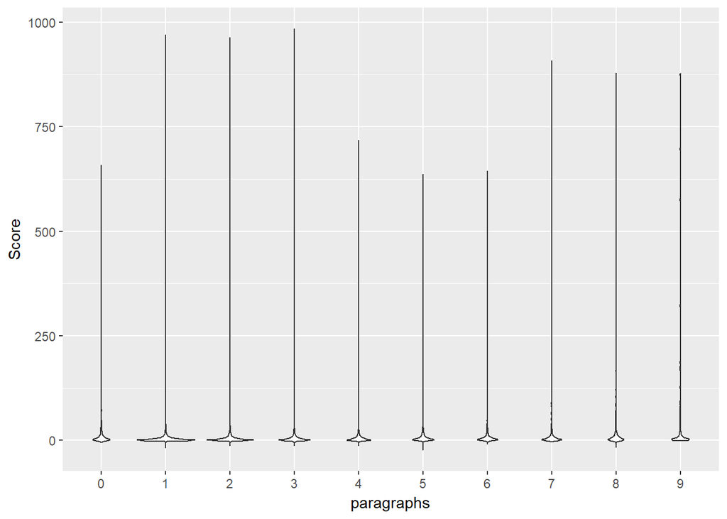

## Summary of Individual Contributions

Sarah: For my individual contribution, I found the number of question marks in the body of each question and the number of paragraphs in the body of each answer, and compared each of these with their score, looking for relationships between the two. I did this to see if longer, more in depth, answers or more broken up answers got higher ratings than simpler ones and to see if more complicated questions got higher or lower ratings.